# R Notebook

```r
framingham <- read.csv("https://raw.githubusercontent.com/fabzy4L/DATA_ANALYTICS/main/FRAMINGHAM/FRAMINGHAM_DATAFRAME.csv")
framingham2 <- read.csv("https://raw.githubusercontent.com/fabzy4L/DATA_ANALYTICS/main/FRAMINGHAM/framingham.csv")
```

`r`r # WHAT IS THE PREVALENCE OF CHD prevchd <- framingham$prevchd #prevchd CHD <- sum(prevchd) CHD

```
[1] 194
```

`r`r CHD/4434*100

```
[1] 4.375282
```

`r`r # 4.37% PREVALENCE

`r`r # 3. ASSOC. BTWN HTN & INCIDENCE OF DEATH 24 YEARS LATER prevhyp <- framingham$prevhyp #sum(prevhyp)

TOTAL = 4434 HTN = 1430 NON_HTN = 4434 - 1430 DEAD = 1550 ALIVE = TOTAL - DEAD DEAD_HTN <- 758 ALIVE_HTN <- 672 ALIVE_NON <- 2212 DEAD_HTN <- 758 DEAD_NON <- 792 ###### HTN

```
[1] 1430
```

`r`r NON_HTN

```
[1] 3004
```

`r`r ALIVE

```
[1] 2884
```

`r`r DEAD

```
[1] 1550
```

`r`r TOTAL

```
[1] 4434
```

`r`r #Incidence is #2x2 plot, DEAD & ALIVE VS NO HTN & HTN # rate ratio = # of people alive w/ hypertension / # of people alive w/o hypertension

[output not shown]

`r`r #probability hypertension phtn <- 1430/4434 #probability Alive pal <- 2884/4434 #hypertension + alive = phtn*pal phtn*pal

```
[1] 0.2097683
```

`r`r prob <- phtn*pal #EXPECTED ALIVE W/ HTN EX_L_HTN <- TOTAL*prob EX_L_HTN

```
[1] 930.1128
```

`r`r chisq.test(test)$observed

```
              Status
Dx             Alive Dead
  Hypertension   672  758
  Non-Case      2212  792
```

`r`r chisq.test(test)$expected

```
              Status
Dx                 Alive      Dead
  Hypertension  930.1128  499.8872
  Non-Case     1953.8872 1050.1128
```

`r`r chisq.test(test)

```
    Pearson's Chi-squared test with Yates' continuity correction

data:  test
X-squared = 301.27, df = 1, p-value < 2.2e-16
```

`r`r #a = Number of dead htn #b = Number of dead non-cases #c = Number of alive htn #d = Number of alive non-cases #OR=a*d/b*c

(DEAD_HTN*ALIVE_NON)/(ALIVE_HTN*DEAD_NON)

```
[1] 3.150358
```

`r`r test

```
              Status
Dx             Alive Dead
  Hypertension   672  758
  Non-Case      2212  792
```

`r`r fisher.test(test)

```
    Fisher's Exact Test for Count Data

data:  test
p-value < 2.2e-16
alternative hypothesis: true odds ratio is not equal to 1
95 percent confidence interval:
 0.2776296 0.3629796
sample estimates:
odds ratio
 0.3175256
```

`r`r #ODDS RATIO = 0.3175

`r`r #RATE RATIO #NON/ALIVE VS ILL/ALIVE OVER 24 YEARS

ALIVE <- 672+2212 DEAD <- 758+792 alive_htn <- 672 alive_non <- 2212 dead_htn <- 758 dead_non <- 792

FREQ_1 = alive_htn/ALIVE FREQ_2 = alive_non/ALIVE FREQ_T <- (FREQ_1)/(FREQ_2) FREQ_T

```
[1] 0.3037975
```

[output not shown]

`r`r mosaicplot(t(test), col=c(‘purple’,‘blue’), main= ‘DX V. STATUS PLOT’)

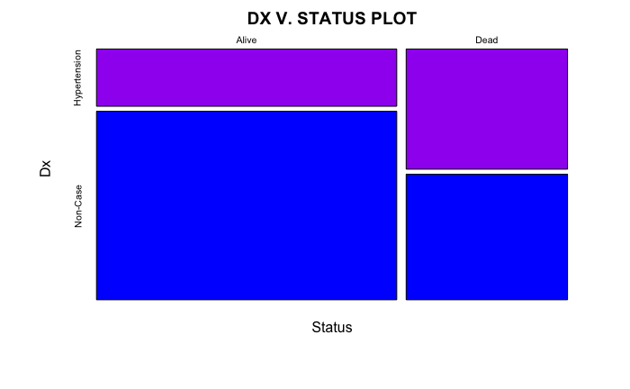

`r`r # INCIDENCE = ANYCHD/HTN

ANYCHD/HTN*100

```
[1] 86.71329
```

[output not shown]

#rate ratio = chd/htn / non/htn

# INCIDENCE = # cases of disease/ population w/o disease at baseline

#sum(framingham$anychd)

#ANYCHD <- 1240 #NONCHD <- 868 + 2326 ##ALIVE_HTN #HTN_CHD <- 562 #HTN_NONCHD <- 868 #CHD_NONHTN <- 678 #NONCHD_NONHTN <- 2326

#NONCHD #ANYCHD #HTN #NON_HTN

FREQ_3 = ANYCHD/HTN FREQ_4 = NONCHD/HTN FREQ_T2 <- (FREQ_3)/(FREQ_4) FREQ_T2*100

```
[1] 38.82279
```

`r`r chisq.test(test_2)$observed

```
              Status
Dx             CHD NON CHD
  Hypertension 562     868
  Non-Case     678    2326
```

`r`r chisq.test(test_2)$expected

```
              Status
Dx                  CHD NON CHD
  Hypertension 399.9098 1030.09
  Non-Case     840.0902 2163.91
```

`r`r chisq.test(test_2)

```
    Pearson's Chi-squared test with Yates' continuity correction

data:  test_2
X-squared = 133.79, df = 1, p-value < 2.2e-16
```